# Fc-OPG PK/PD in healthy post-menopausal women

Metrum Research Group

# 1 Packages

```r
library(mrgsolve)
library(tidyverse)
library(magrittr)
library(furrr)
```

## 1.1 Question

- What is the median change from baseline 14 days after 3 mg/kg SC dose?
- What is the probability that median CFB is greater than 40%?

# 2 OPG model

```r
mod <- mread("opg", "../model")

mod
```

```
.
.
. ----------------  source: opg.cpp  ----------------
.
.   project: /Users/kyleb/ghe...raining/model
.   shared object: opg-so-f30918d45bc3
.
.   time:          start: 0 end: 24 delta: 1
.                  add: <none>
.
.   compartments:  SC CENT P1 P2 NTX [5]
.   parameters:    IV TVCL TVVC TVVP1 TVVP2 TVQ1 TVQ2 TVKA
.                  TVVMAX TVKM TVFSC TVKSYN TVKDEG TVIC50 [14]
.   captures:      PKDV PDDV dNTX [3]
.   omega:         7x7,3x3
.   sigma:         2x2,2x2
.
.   solver:        atol: 1e-08 rtol: 1e-08 maxsteps: 5000
```

Checkout the random effects structure

```r
revar(mod)
```

```
. $omega
. $...
.          [,1]   [,2]   [,3]   [,4]   [,5]   [,6]  [,7]
. ECL:   0.0391 0.0000 0.0000 0.0000 0.0000 0.0000 0.000
. EVC:   0.0000 0.0102 0.0000 0.0000 0.0000 0.0000 0.000
. EVP1:  0.0000 0.0000 0.0144 0.0000 0.0000 0.0000 0.000
. EVP2:  0.0000 0.0000 0.0000 0.0333 0.0000 0.0000 0.000
. EQ1:   0.0000 0.0000 0.0000 0.0000 0.0379 0.0000 0.000
. EKA:   0.0000 0.0000 0.0000 0.0000 0.0000 0.0457 0.000
. EFSC:  0.0000 0.0000 0.0000 0.0000 0.0000 0.0000 0.263
.
. $...
.           [,1]   [,2] [,3]
. EKSYN:  0.2810 0.0867 0.00
. EKDEG:  0.0867 0.0325 0.00
. EIC50:  0.0000 0.0000 1.18
.
.
. $sigma
. $...
.           [,1]  [,2]
. ADDIV:  0.0193 0.000
. ADDSC:  0.0000 0.733
.
. $...
.            [,1] [,2]
. PDPROP:  0.0407  0.0
. PDADD:   0.0000 20.7
```

```r
mod %<>% mrgsolve:::collapse_omega()
mod %<>% mrgsolve:::collapse_sigma()
```

# 3 Load the simulated posterior

```r
post <- readRDS("../data/opgpost.RDS") %>% sample_n(1000)

post %>% head
```

```
.    TVCL TVVC  TVP1  TVP2   TVQ1  TVQ2    TVKA TVVMAX  TVKM  TVFSC TVKSYN
. 1 167.2 2835 505.2 222.7 12.130 2.738 0.01267  10220 7.120 0.0719 0.7206
. 2 156.8 2649 538.6 222.5  9.945 3.236 0.01274  14360 7.177 0.0719 0.9254
. 3 169.8 2784 445.2 256.6 16.140 2.861 0.01288  13280 6.588 0.0719 0.9404
. 4 157.9 2727 521.5 275.1 14.440 2.461 0.01238  14970 7.621 0.0719 0.7952
. 5 178.0 2807 378.4 311.0 15.160 3.590 0.01376  13330 7.204 0.0719 0.9738
. 6 175.2 2914 436.1 257.6 15.030 3.263 0.01322  13170 7.320 0.0719 0.7941
.    TVKDEG TVIC50 OMEGA11   OMEGA21 OMEGA22   OMEGA31   OMEGA32 OMEGA33
. 1 0.01913  5.839 0.04424 -0.001764 0.01332  0.002795  0.000308 0.01934
. 2 0.01756  6.045 0.04513 -0.001575 0.01147  0.001226 -0.001308 0.01595
. 3 0.01925  6.660 0.04007  0.002882 0.01150 -0.001938 -0.000981 0.01654
. 4 0.02224  4.710 0.04635 -0.004248 0.01265 -0.002105  0.005945 0.01679
. 5 0.02112  2.812 0.05415 -0.005457 0.01074 -0.001443  0.001742 0.01298
. 6 0.02059  5.556 0.04665 -0.000545 0.01780 -0.003842  0.001231 0.01374
.     OMEGA41   OMEGA42   OMEGA43 OMEGA44   OMEGA51   OMEGA52   OMEGA53
. 1 -0.004537  0.001019  0.002380 0.03429 -0.002902 -0.000666  0.002210
. 2  0.006837 -0.002623  0.002805 0.03278 -0.002732 -0.002553 -0.002110
. 3 -0.001223  0.000836  0.002130 0.03511  0.008505  0.003718  0.000182
. 4 -0.000328 -0.001768 -0.000236 0.03635  0.003201 -0.002392 -0.000475
. 5 -0.006323  0.003897  0.001702 0.02693 -0.007249 -0.000288  0.003324
. 6  0.005940  0.001159  0.000438 0.03061  0.002062  0.003099 -0.002398
.     OMEGA54 OMEGA55   OMEGA61   OMEGA62   OMEGA63   OMEGA64  OMEGA65
. 1  0.005406 0.03806  0.003639 -0.001591  0.001177 -0.000810 0.005419
. 2 -0.003072 0.04909  0.000671 -0.001634 -0.003739  0.005185 0.002561
. 3 -0.001933 0.04006 -0.003529  0.001376  0.002139  0.003343 0.004861
. 4  0.006233 0.03614 -0.001784  0.000401 -0.004168 -0.003969 0.005399
. 5 -0.002094 0.04290  0.001911 -0.000708 -0.000100 -0.005059 0.001521
. 6  0.000043 0.03917  0.007427  0.008495  0.000252  0.005755 0.001643
.   OMEGA66   OMEGA71   OMEGA72   OMEGA73   OMEGA74   OMEGA75   OMEGA76
. 1 0.05010 -0.010410  0.003260 -0.011470  0.009115  0.004890  0.005778
. 2 0.05675 -0.009637 -0.008940 -0.004985  0.000506  0.011360 -0.009145
. 3 0.05213  0.005951  0.005638 -0.005218  0.010070 -0.006570 -0.017530
. 4 0.05666 -0.009182  0.008999  0.000544 -0.011420 -0.024820 -0.002828
. 5 0.03557 -0.024300  0.007049  0.000622  0.006520  0.008456  0.003942
. 6 0.05565  0.014430  0.035890  0.011070  0.019730 -0.026890  0.035440
.   OMEGA77   OMEGA81  OMEGA82   OMEGA83   OMEGA84   OMEGA85   OMEGA86
. 1  0.3238  0.011730 0.006579  0.006028  0.006934  0.013510  0.016110
. 2  0.3084 -0.010310 0.003832  0.003848 -0.002811  0.007963 -0.006598
. 3  0.3250  0.000578 0.006237 -0.002624  0.012220  0.012360  0.017970
. 4  0.3149  0.002734 0.008728  0.013450 -0.032300 -0.017660  0.020390
```

[output cut: 22 more lines]

```
. 6 -0.025000  0.013340 -0.036940 -0.09304  0.06915  0.019960     1.131
.   SIGMA11   SIGMA21 SIGMA22   SIGMA31   SIGMA32 SIGMA33   SIGMA41  SIGMA42
. 1 0.01844 -0.002036  0.7165  0.001677 -0.003482 0.04338 -0.037360  0.08066
. 2 0.02097  0.001016  0.6636 -0.000912  0.008253 0.03997  0.023060  0.09893
. 3 0.01929  0.001523  0.7091  0.000107 -0.006074 0.04204  0.003887 -0.09970
. 4 0.01847  0.001713  0.8334 -0.000435 -0.010250 0.04192 -0.009114 -0.03912
. 5 0.01842 -0.000169  0.7102  0.000120 -0.004873 0.04053 -0.024510 -0.04808
. 6 0.01780 -0.008663  0.7882 -0.000282  0.003101 0.04307 -0.005529  0.11170
.     SIGMA43 SIGMA44
. 1 -0.006900   20.11
. 2 -0.020650   20.81
. 3 -0.000649   20.58
. 4 -0.032770   21.48
. 5 -0.018750   21.27
. 6 -0.012070   20.33
```

```r
param(mod)
```

```
.
.  Model parameters (N=14):
.  name   value  . name   value
.  IV     0      | TVKSYN 0.864
.  TVCL   168    | TVQ1   15.5
.  TVFSC  0.0719 | TVQ2   3.02
.  TVIC50 5.38   | TVVC   2800
.  TVKA   0.0131 | TVVMAX 13300
.  TVKDEG 0.0204 | TVVP1  443
.  TVKM   6.74   | TVVP2  269
```

For most of our examples, we are taking output directly from a NONMEM run. This example is a little different: We have changed the column names from `THETA1`, `THETA2` etc … to `TVCL`, `TVVC` etc …

```r
head(post)

inventory(mod,post)
```

[output not shown]

```r
post <- mutate(post, TVVP1 = TVP1, TVVP2 = TVP2)
```

When working with results out of NONMEM, it is common to get the `THETA` , `OMEGA` and `SIGMA` estimates all in a single row in a data frame.

In order to get the information for `OMEGA` and `SIGMA` in to the problem, we need to go into this data and form matrices.

There are two specialized functions to help with this:

- `as_bmat` when the data is in block format
- `as_dmat` when the data is in diagonal format

```r
omegas <- as_bmat(post,"OMEGA")
sigmas <- as_bmat(post,"SIGMA")

omegas[[10]]
```

```
.            [,1]      [,2]      [,3]      [,4]      [,5]      [,6]
.  [1,]  0.049050 -0.002652  0.001404 -0.003970  0.002456  0.001178
.  [2,] -0.002652  0.012660 -0.002820  0.003165 -0.003402  0.000957
.  [3,]  0.001404 -0.002820  0.015910  0.000152  0.005142 -0.002826
.  [4,] -0.003970  0.003165  0.000152  0.029890 -0.000830 -0.002210
.  [5,]  0.002456 -0.003402  0.005142 -0.000830  0.037470 -0.006536
.  [6,]  0.001178  0.000957 -0.002826 -0.002210 -0.006536  0.045150
.  [7,] -0.021430  0.006792  0.003321  0.009433  0.008259 -0.011530
.  [8,] -0.014900 -0.000725 -0.004888 -0.008591 -0.011750 -0.007458
.  [9,] -0.003248 -0.000324 -0.003288 -0.003784 -0.003542 -0.004322
. [10,] -0.017690 -0.011210  0.004992 -0.012280  0.009096  0.013140
.            [,7]      [,8]      [,9]     [,10]
.  [1,] -0.021430 -0.014900 -0.003248 -0.017690
.  [2,]  0.006792 -0.000725 -0.000324 -0.011210
.  [3,]  0.003321 -0.004888 -0.003288  0.004992
.  [4,]  0.009433 -0.008591 -0.003784 -0.012280
.  [5,]  0.008259 -0.011750 -0.003542  0.009096
.  [6,] -0.011530 -0.007458 -0.004322  0.013140
.  [7,]  0.237000  0.006232  0.001199  0.015480
.  [8,]  0.006232  0.413000  0.135300 -0.135400
.  [9,]  0.001199  0.135300  0.051270 -0.051320
. [10,]  0.015480 -0.135400 -0.051320  1.278000
```

```r
length(omegas)
```

```
. [1] 1000
```

```r
is.list(omegas)
```

```
. [1] TRUE
```

```r
slice(post, 10)
```

```
.   TVCL TVVC  TVP1  TVP2 TVQ1  TVQ2    TVKA TVVMAX  TVKM  TVFSC TVKSYN
. 1  171 2805 473.1 176.5 15.8 2.662 0.01323  16100 7.537 0.0719 0.8489
.    TVKDEG TVIC50 OMEGA11   OMEGA21 OMEGA22  OMEGA31  OMEGA32 OMEGA33
. 1 0.02103  3.685 0.04905 -0.002652 0.01266 0.001404 -0.00282 0.01591
.    OMEGA41  OMEGA42  OMEGA43 OMEGA44  OMEGA51   OMEGA52  OMEGA53  OMEGA54
. 1 -0.00397 0.003165 0.000152 0.02989 0.002456 -0.003402 0.005142 -0.00083
.   OMEGA55  OMEGA61  OMEGA62   OMEGA63  OMEGA64   OMEGA65 OMEGA66  OMEGA71
. 1 0.03747 0.001178 0.000957 -0.002826 -0.00221 -0.006536 0.04515 -0.02143
.    OMEGA72  OMEGA73  OMEGA74  OMEGA75  OMEGA76 OMEGA77 OMEGA81   OMEGA82
. 1 0.006792 0.003321 0.009433 0.008259 -0.01153   0.237 -0.0149 -0.000725
.     OMEGA83   OMEGA84  OMEGA85   OMEGA86  OMEGA87 OMEGA88   OMEGA91
. 1 -0.004888 -0.008591 -0.01175 -0.007458 0.006232   0.413 -0.003248
.     OMEGA92   OMEGA93   OMEGA94   OMEGA95   OMEGA96  OMEGA97 OMEGA98
. 1 -0.000324 -0.003288 -0.003784 -0.003542 -0.004322 0.001199  0.1353
.   OMEGA99 OMEGA101 OMEGA102 OMEGA103 OMEGA104 OMEGA105 OMEGA106 OMEGA107
. 1 0.05127 -0.01769 -0.01121 0.004992 -0.01228 0.009096  0.01314  0.01548
.   OMEGA108 OMEGA109 OMEGA1010 SIGMA11   SIGMA21 SIGMA22  SIGMA31  SIGMA32
. 1  -0.1354 -0.05132     1.278  0.0192 -0.003811  0.7671 0.000671 0.001322
.   SIGMA33  SIGMA41 SIGMA42 SIGMA43 SIGMA44 TVVP1 TVVP2
. 1 0.04136 0.008562 -0.0697 -0.0246   19.06 473.1 176.5
```

```r
omegas[[10]]
```

```
.            [,1]      [,2]      [,3]      [,4]      [,5]      [,6]
.  [1,]  0.049050 -0.002652  0.001404 -0.003970  0.002456  0.001178
.  [2,] -0.002652  0.012660 -0.002820  0.003165 -0.003402  0.000957
.  [3,]  0.001404 -0.002820  0.015910  0.000152  0.005142 -0.002826
.  [4,] -0.003970  0.003165  0.000152  0.029890 -0.000830 -0.002210
.  [5,]  0.002456 -0.003402  0.005142 -0.000830  0.037470 -0.006536
.  [6,]  0.001178  0.000957 -0.002826 -0.002210 -0.006536  0.045150
.  [7,] -0.021430  0.006792  0.003321  0.009433  0.008259 -0.011530
.  [8,] -0.014900 -0.000725 -0.004888 -0.008591 -0.011750 -0.007458
.  [9,] -0.003248 -0.000324 -0.003288 -0.003784 -0.003542 -0.004322
. [10,] -0.017690 -0.011210  0.004992 -0.012280  0.009096  0.013140
.            [,7]      [,8]      [,9]     [,10]
.  [1,] -0.021430 -0.014900 -0.003248 -0.017690
.  [2,]  0.006792 -0.000725 -0.000324 -0.011210
.  [3,]  0.003321 -0.004888 -0.003288  0.004992
.  [4,]  0.009433 -0.008591 -0.003784 -0.012280
.  [5,]  0.008259 -0.011750 -0.003542  0.009096
.  [6,] -0.011530 -0.007458 -0.004322  0.013140
.  [7,]  0.237000  0.006232  0.001199  0.015480
.  [8,]  0.006232  0.413000  0.135300 -0.135400
.  [9,]  0.001199  0.135300  0.051270 -0.051320
. [10,]  0.015480 -0.135400 -0.051320  1.278000
```

```r
sigmas[[10]]
```

```
.           [,1]      [,2]      [,3]      [,4]
. [1,]  0.019200 -0.003811  0.000671  0.008562
. [2,] -0.003811  0.767100  0.001322 -0.069700
. [3,]  0.000671  0.001322  0.041360 -0.024600
. [4,]  0.008562 -0.069700 -0.024600 19.060000
```

Here is a simple dosing data set to simulate 100 patients with 3 mg/kg Fc-OPG SC x1

```r
sc3 <- expand.ev(ID=1:100, amt=210)

head(sc3)
```

```
.   ID amt evid cmt time
. 1  1 210    1   1    0
. 2  2 210    1   1    0
. 3  3 210    1   1    0
. 4  4 210    1   1    0
. 5  5 210    1   1    0
. 6  6 210    1   1    0
```

We will get the observation design for the simulation through a `tgrid` object

```r
stime(tgrid(0, 12, 6) + 24)
```

```
. [1] 24 30 36
```

```r
des <- tgrid(end=-1,add=c(0,24*14))

des
```

```
. start:  0  end:    -1  delta:  1  offset: 0  min:    0   max:    336
```

When we do replicate simulation, it almost always pays off to construct a function that will carry out one replicate.

Arguments to the function are

- `i` the current simulation replicate
- `data` the dosing data set
- `des` the observation design

```r
sim <- function(i,data,des) {

  mod <-
    mod %>%
    param(slice(post,i)) %>%
    omat(omegas[[i]]) %>%
    smat(sigmas[[i]])

  mod %>%
    Req(PDDV) %>%
    mrgsim(data=data,tgrid=des,obsonly=TRUE) %>%
    mutate(irep=i) %>%
    mutate(TVIC50=mod$TVIC50, TVQ1=mod$TVQ1, TVVMAX=mod$TVVMAX)
}
```

It is easy to test the function. The 10th replicate will look like this

```r
sim(10,sc3,des)
```

```
. # A tibble: 200 x 7
.       ID  time  PDDV  irep TVIC50  TVQ1 TVVMAX
.    <dbl> <dbl> <dbl> <dbl>  <dbl> <dbl>  <dbl>
.  1     1     0 78.8     10   3.68  15.8  16100
.  2     1   336 41.5     10   3.68  15.8  16100
.  3     2     0 45.9     10   3.68  15.8  16100
.  4     2   336  9.88    10   3.68  15.8  16100
.  5     3     0 37.7     10   3.68  15.8  16100
.  6     3   336 20.0     10   3.68  15.8  16100
.  7     4     0 32.1     10   3.68  15.8  16100
.  8     4   336 -4.46    10   3.68  15.8  16100
.  9     5     0 20.4     10   3.68  15.8  16100
. 10     5   336 25.1     10   3.68  15.8  16100
. # … with 190 more rows
```

```r
slice(post, 10)
```

```
.   TVCL TVVC  TVP1  TVP2 TVQ1  TVQ2    TVKA TVVMAX  TVKM  TVFSC TVKSYN
. 1  171 2805 473.1 176.5 15.8 2.662 0.01323  16100 7.537 0.0719 0.8489
.    TVKDEG TVIC50 OMEGA11   OMEGA21 OMEGA22  OMEGA31  OMEGA32 OMEGA33
. 1 0.02103  3.685 0.04905 -0.002652 0.01266 0.001404 -0.00282 0.01591
.    OMEGA41  OMEGA42  OMEGA43 OMEGA44  OMEGA51   OMEGA52  OMEGA53  OMEGA54
. 1 -0.00397 0.003165 0.000152 0.02989 0.002456 -0.003402 0.005142 -0.00083
.   OMEGA55  OMEGA61  OMEGA62   OMEGA63  OMEGA64   OMEGA65 OMEGA66  OMEGA71
. 1 0.03747 0.001178 0.000957 -0.002826 -0.00221 -0.006536 0.04515 -0.02143
.    OMEGA72  OMEGA73  OMEGA74  OMEGA75  OMEGA76 OMEGA77 OMEGA81   OMEGA82
. 1 0.006792 0.003321 0.009433 0.008259 -0.01153   0.237 -0.0149 -0.000725
.     OMEGA83   OMEGA84  OMEGA85   OMEGA86  OMEGA87 OMEGA88   OMEGA91
. 1 -0.004888 -0.008591 -0.01175 -0.007458 0.006232   0.413 -0.003248
.     OMEGA92   OMEGA93   OMEGA94   OMEGA95   OMEGA96  OMEGA97 OMEGA98
. 1 -0.000324 -0.003288 -0.003784 -0.003542 -0.004322 0.001199  0.1353
.   OMEGA99 OMEGA101 OMEGA102 OMEGA103 OMEGA104 OMEGA105 OMEGA106 OMEGA107
. 1 0.05127 -0.01769 -0.01121 0.004992 -0.01228 0.009096  0.01314  0.01548
.   OMEGA108 OMEGA109 OMEGA1010 SIGMA11   SIGMA21 SIGMA22  SIGMA31  SIGMA32
. 1  -0.1354 -0.05132     1.278  0.0192 -0.003811  0.7671 0.000671 0.001322
.   SIGMA33  SIGMA41 SIGMA42 SIGMA43 SIGMA44 TVVP1 TVVP2
. 1 0.04136 0.008562 -0.0697 -0.0246   19.06 473.1 176.5
```

Simulate reps

```r
set.seed(22223)

out <- future_map_dfr(1:1000, sim, data=sc3, des=des)

head(out)
```

```
. # A tibble: 6 x 7
.      ID  time  PDDV  irep TVIC50  TVQ1 TVVMAX
.   <dbl> <dbl> <dbl> <int>  <dbl> <dbl>  <dbl>
. 1     1     0  60.1     1   5.84  12.1  10220
. 2     1   336  13.7     1   5.84  12.1  10220
. 3     2     0  75.1     1   5.84  12.1  10220
. 4     2   336  33.4     1   5.84  12.1  10220
. 5     3     0  49.9     1   5.84  12.1  10220
. 6     3   336  36.9     1   5.84  12.1  10220
```

Summarise

- First, get the baseline `NTX`
- Then calculate percent CFB

```r
sum <-
  out %>%
  group_by(ID,irep) %>%
  mutate(BASE = first(PDDV), dDV = 100*(PDDV-BASE)/BASE) %>%
  ungroup

head(sum)
```

```
. # A tibble: 6 x 9
.      ID  time  PDDV  irep TVIC50  TVQ1 TVVMAX  BASE   dDV
.   <dbl> <dbl> <dbl> <int>  <dbl> <dbl>  <dbl> <dbl> <dbl>
. 1     1     0  60.1     1   5.84  12.1  10220  60.1   0
. 2     1   336  13.7     1   5.84  12.1  10220  60.1 -77.1
. 3     2     0  75.1     1   5.84  12.1  10220  75.1   0
. 4     2   336  33.4     1   5.84  12.1  10220  75.1 -55.6
. 5     3     0  49.9     1   5.84  12.1  10220  49.9   0
. 6     3   336  36.9     1   5.84  12.1  10220  49.9 -26.2
```

Filter down to week 2

```r
sum <- sum %>% filter(time==336 & BASE >= 0)
```

Now, get the median

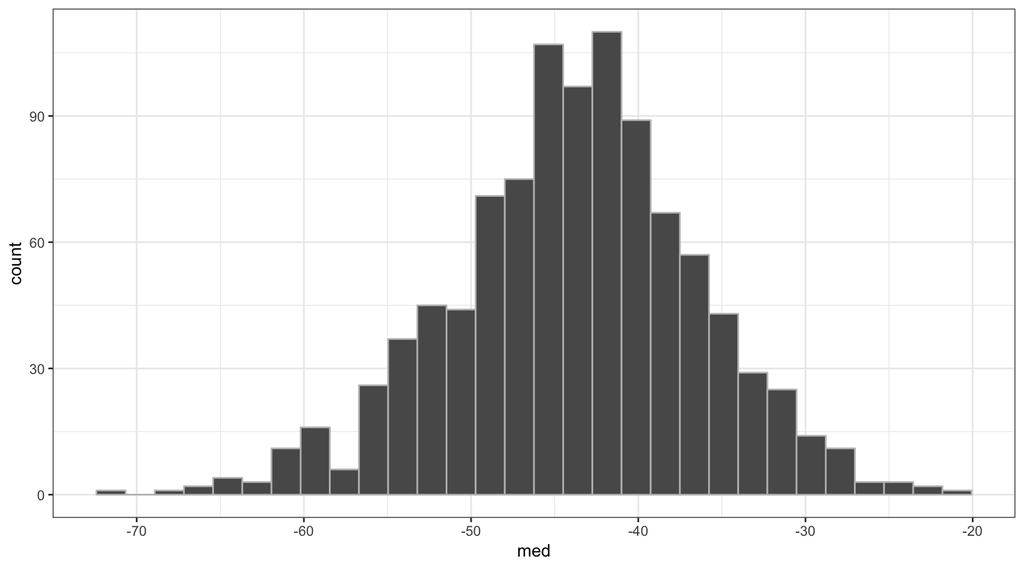

```r
summ <-
  sum %>%
  filter(time==336) %>%
  group_by(irep) %>%
  summarise(med = median(dDV))

ggplot(summ, aes( x = med)) + geom_histogram( col = "grey")
```

```r
summ
```

```
. # A tibble: 1,000 x 2
.     irep   med
.    <int> <dbl>
.  1     1 -49.8
.  2     2 -43.5
.  3     3 -40.4
.  4     4 -51.0
.  5     5 -53.1
.  6     6 -52.6
.  7     7 -41.8
.  8     8 -40.7
.  9     9 -30.0
. 10    10 -45.7
. # … with 990 more rows
```

## 3.1 From the abstract

> Subsequent clinical trial simulations demonstrated that a single 3.0-mg/kg SC dose of Fc-OPG would be expected to produce, at 14 days post-dose, a median NTX percentage change from baseline of −45% (with a 95% prediction interval ranging from −34% to −60%)."

```r
ans <- signif(quantile(summ$med, c(0.5,0.025,0.975)),3)

paste0(ans[1], " (", ans[3],",",ans[2],")")
```

```
. [1] "-43.7 (-30,-59.8)"
```

Median week-2 change from baseline with 95% interval

Probability that median cfb > 40%

```r
mean(summ$med < -40)
```

```
. [1] 0.711
```

Plot the distribution of the week-2 change from baseline

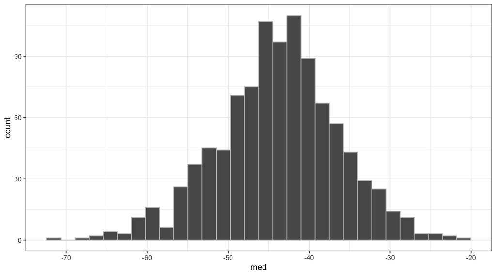

```r
ggplot(summ, aes(x=med)) + geom_histogram(col="grey")
```

# 4 Sensitivity analysis

We are already set up to do the sensitivity analysis

```r
par <- dplyr::distinct(out,irep,TVIC50,TVQ1,TVVMAX)
head(par)
```

```
. # A tibble: 6 x 4
.    irep TVIC50  TVQ1 TVVMAX
.   <int>  <dbl> <dbl>  <dbl>
. 1     1   5.84 12.1   10220
. 2     2   6.04  9.94  14360
. 3     3   6.66 16.1   13280
. 4     4   4.71 14.4   14970
. 5     5   2.81 15.2   13330
. 6     6   5.56 15.0   13170
```

```r
sens <- left_join(summ,par)
head(sens)
```

```
. # A tibble: 6 x 5
.    irep   med TVIC50  TVQ1 TVVMAX
.   <int> <dbl>  <dbl> <dbl>  <dbl>
. 1     1 -49.8   5.84 12.1   10220
. 2     2 -43.5   6.04  9.94  14360
. 3     3 -40.4   6.66 16.1   13280
. 4     4 -51.0   4.71 14.4   14970
. 5     5 -53.1   2.81 15.2   13330
. 6     6 -52.6   5.56 15.0   13170
```

`TVIC50`

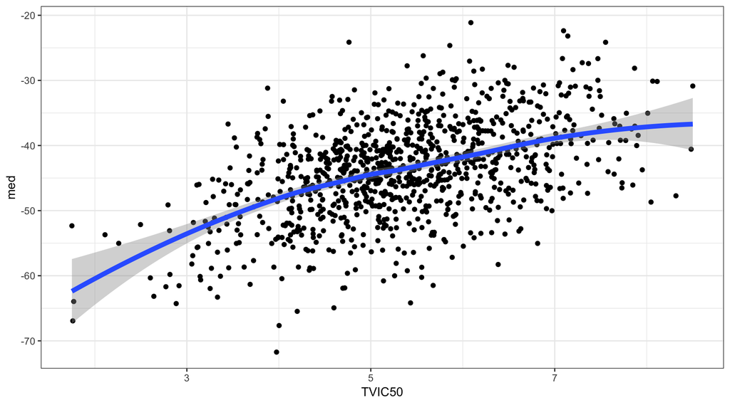

```r
ggplot(sens, aes(TVIC50, med)) +
  geom_point() +
  geom_smooth(method="loess",lwd=2)
```

`TVVMAX`

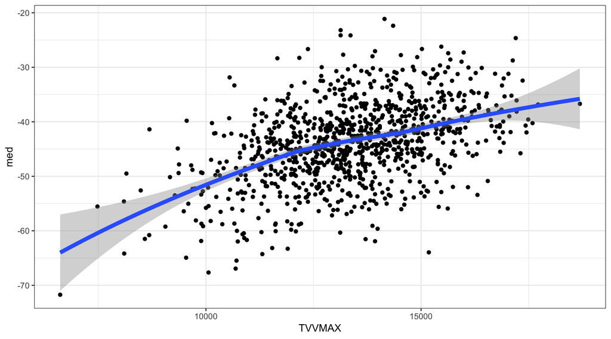

```r
ggplot(sens, aes(TVVMAX, med)) +
  geom_point() +
  geom_smooth(method="loess",lwd=2)
```

`TVQ`

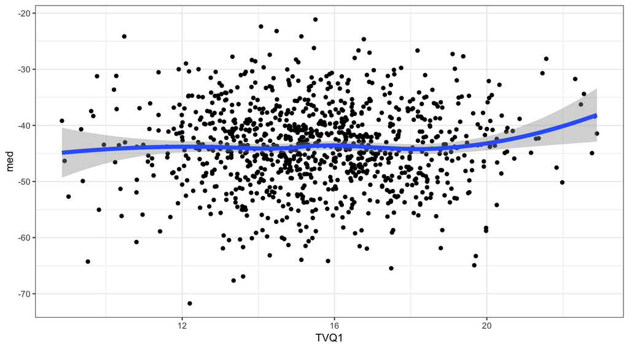

```r
ggplot(sens, aes(TVQ1, med)) +
  geom_point() +
  geom_smooth(method="loess",lwd=2)
```